# Part 2: Data Visualization with Python

## This script includes the following points:

### 1. Import data

### 2. Create a bar chart, histogram, scatterplot, and line chart from sample set.

### 3. Create a histogram of the "order_hour_of_day" column.

### 4. Create a bar chart from the "loyalty_flag" column.

### 5. Check whether there's a difference in expenditure depending on hour of day.

### 6. Line chart exploring connection between age and family situation.

### 7. Scatterplot exploring connection between age and income.

### 8. Export visualizations.

```python
#Import Libraries
import pandas as pd
import numpy as np
import os
import matplotlib.pyplot as plt
import seaborn as sns
import scipy
```

### 1. Import data

```python
#Import Data
path = r'C:\Users\Marlo\OneDrive - South Washington County Schools\Home\job support\Coursework\Achievement 4\Instacart Basket Analysis'
```

```python
ords_prods_merge = pd.read_pickle(os.path.join(path, '02 Data', 'Prepared Data', 'ords_prods_agg.pkl'))
```

```python
ords_prods_cust_merge = pd.read_pickle(os.path.join(path, '02 Data', 'Prepared Data', 'ords_prods_cust.pkl'))
```

### 2. Create a bar chart, histogram, scatterplot, and line chart from sample set.

#### 2a. bar chart

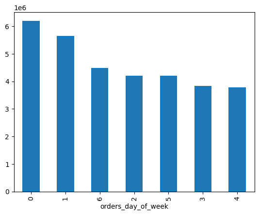

```python
#create a bar chart
ords_prods_merge['orders_day_of_week'].value_counts().plot.bar()
```

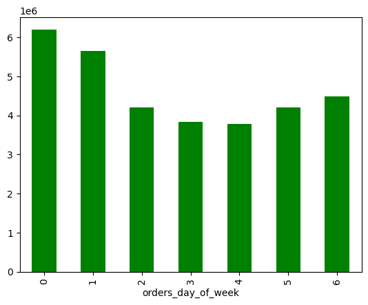

```python
# create a bar chart with days of week in order
ords_prods_merge['orders_day_of_week'].value_counts().sort_index().plot.bar(color = ['green'])
```

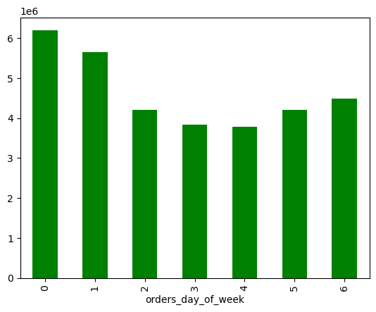

```python
#Assign name to bar graph
bar = ords_prods_merge['orders_day_of_week'].value_counts().sort_index().plot.bar(color = ['green'])
```

```python
#Export bar graph
bar.figure.savefig(os.path.join(path, '04 Analysis', 'Visualizations', 'bar_graph_dow.png'))
```

#### 2b. Histograms and Scatterplots

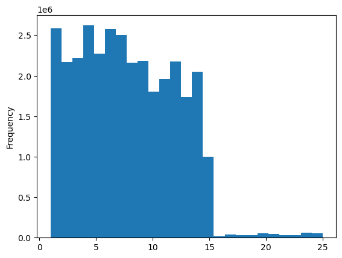

```python
#Create a histogram on prices
hist = ords_prods_merge['prices'].plot.hist(bins = 25)
```

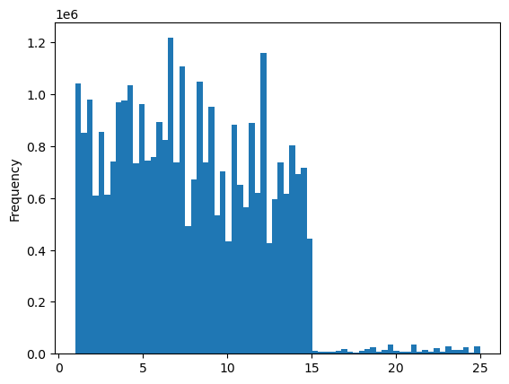

```python
hist_2 = ords_prods_merge['prices'].plot.hist(bins=70)
```

```python
#export histogram
hist_2.figure.savefig(os.path.join(path, '04 Analysis', 'Visualizations', 'hist_prices.png'))
```

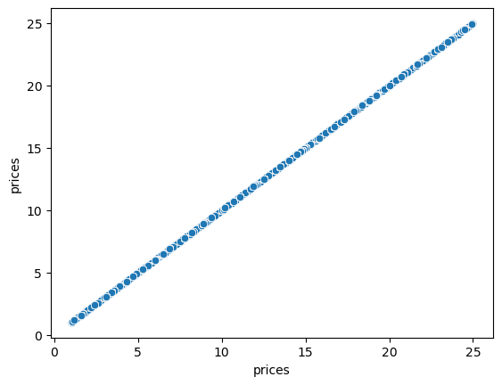

```python
#create scatterplot of prices
scatter = sns.scatterplot(x='prices', y='prices', data = ords_prods_merge)
```

#### 2c. Create Sample

```python
#create seed
np.random.seed(4)
```

```python
#Create a list holding True/False values to the test np.random.rant() <=0.7
dev = np.random.rand(len(ords_prods_merge)) <=0.7
```

```python
#Store 70% of the sample in the dataframe big
big = ords_prods_merge[dev]
```

```python
#Store 30% of the sample in the dataframe small
small = ords_prods_merge[~dev]
```

```python
#Check number of rows in samples vs. entire dataset
len(ords_prods_merge)
```

```
32404859
```

```python
len(big)+len(small)
```

```
32404859
```

```python
#Reduce sample to only columns "prices" and "orders_day_of_week"
df_2 = small[['orders_day_of_week', 'prices']]
```

#### 2d. Line Chart

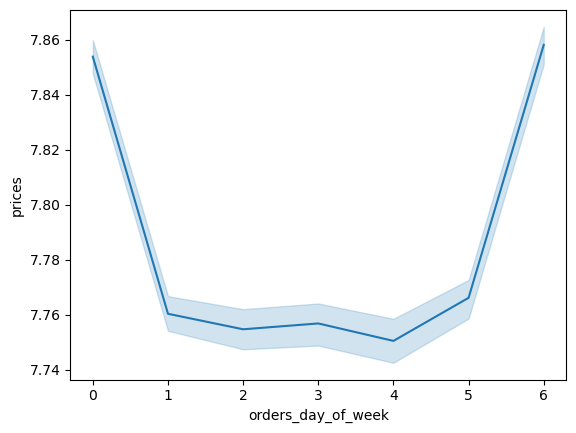

```python
line = sns.lineplot(data = df_2, x = 'orders_day_of_week', y = 'prices')
```

```python
ords_prods_merge.info()
```

```
<class 'pandas.core.frame.DataFrame'>
RangeIndex: 32404859 entries, 0 to 32404858
Data columns (total 20 columns):
 #   Column                         Dtype
---  ------                         -----
 0   product_id                     int64
 1   product_name                   object
 2   aisle_id                       int64
 3   department_id                  int64
 4   prices                         float64
 5   order_id                       int64
 6   user_id                        int64
 7   order_number                   int64
 8   orders_day_of_week             int64
 9   order_hour_of_day              int64
 10  days_since_prior_order         float64
 11  add_to_cart_order              int64
 12  reordered                      int64
 13  _merge                         category
 14  max_order                      int64
 15  loyalty_flag                   object
 16  mean_prices                    float64
 17  spending_flag                  object
 18  median_days_since_prior_order  float64
 19  frequency_flag                 object
dtypes: category(1), float64(4), int64(11), object(4)
memory usage: 4.6+ GB
```

### 3. Create a histogram of the "order_hour_of_day" column

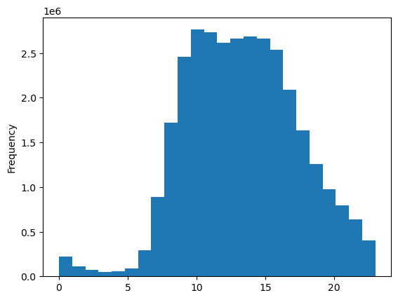

```python
#Create historgram about order hour of day
hist_hour = ords_prods_cust_merge['order_hour_of_day'].plot.hist(bins = 24)
```

The histogram shows that most orders take place between hours 8-18. The least amount of orders take place between hours 0-6.

### 4. Create a bar chart from the "loyalty_flag" column.

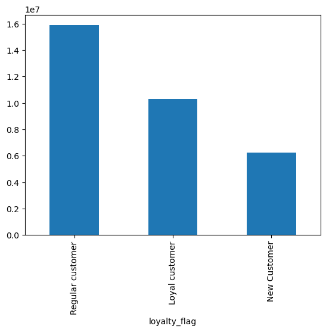

```python
#create bar chart showing customer loyalty
bar_loyalty = ords_prods_cust_merge['loyalty_flag'].value_counts().plot.bar()
```

### 5. Check whether there's a difference in expenditure depending on hour of day.

```python
#create a seed
np.random.seed(4)
```

```python
#Create a list holding True/False values to the test np.random.rant() <=0.7
dev = np.random.rand(len(ords_prods_cust_merge)) <= 0.7
```

```python
#Store 70% of the sample in the dataframe big_1
big_1 = ords_prods_cust_merge[dev]
```

```python
#Store 30% of the sample in the dataframe small
small_1 = ords_prods_cust_merge[~dev]
```

```python
#Check number of rows in ords_prods_cust_merge
len(ords_prods_cust_merge)
```

```
32404859
```

```python
#check number of rows in big_1 + small_1
len(big_1)+len(small_1)
```

```
32404859
```

```python
#Make data set that only includes the columns order_hour_of_day and prices
merge_sample = small_1[['order_hour_of_day', 'prices']]
```

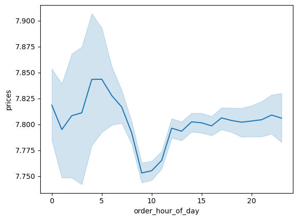

```python
#Create line graph showing prices depending on order hour of day
line_1 = sns.lineplot(data = merge_sample, x = 'order_hour_of_day', y = 'prices')
```

### 6. Line chart exploring connection between age and family situation.

```python
ords_prods_cust_merge.head()
```

|  | product_id | product_name | aisle_id | department_id | prices | order_id | user_id | order_number | orders_day_of_week | order_hour_of_day | ... | frequency_flag | first_name | surname | gender | state | age | date_joined | number_of_dependants | fam_status | income |
| --- | --- | --- | --- | --- | --- | --- | --- | --- | --- | --- | --- | --- | --- | --- | --- | --- | --- | --- | --- | --- | --- |
| 0 | 1 | Chocolate Sandwich Cookies | 61 | 19 | 5.8 | 3139998 | 138 | 28 | 6 | 11 | ... | frequent customer | Charles | Cox | Male | Minnesota | 81 | 8/1/2019 | 1 | married | 49620 |
| 1 | 1 | Chocolate Sandwich Cookies | 61 | 19 | 5.8 | 1977647 | 138 | 30 | 6 | 17 | ... | frequent customer | Charles | Cox | Male | Minnesota | 81 | 8/1/2019 | 1 | married | 49620 |
| 2 | 907 | Premium Sliced Bacon | 106 | 12 | 20.0 | 3160996 | 138 | 1 | 5 | 13 | ... | frequent customer | Charles | Cox | Male | Minnesota | 81 | 8/1/2019 | 1 | married | 49620 |
| 3 | 907 | Premium Sliced Bacon | 106 | 12 | 20.0 | 2254091 | 138 | 10 | 5 | 14 | ... | frequent customer | Charles | Cox | Male | Minnesota | 81 | 8/1/2019 | 1 | married | 49620 |
| 4 | 1000 | Apricots | 18 | 10 | 12.9 | 505689 | 138 | 9 | 6 | 12 | ... | frequent customer | Charles | Cox | Male | Minnesota | 81 | 8/1/2019 | 1 | married | 49620 |

5 rows × 29 columns

```python
#Make data set that only include age and family status
merge_sample_2 = small_1[['age', 'fam_status']]
```

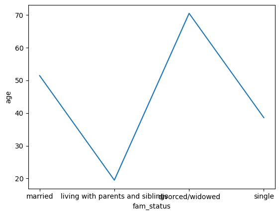

```python
#Create line graph showing age and family status
line_2 = sns.lineplot(data = merge_sample_2, x = 'fam_status', y = 'age')
```

```python
ords_prods_cust_merge['fam_status'].value_counts()
```

```
fam_status
married                             22756753
single                               5325691
divorced/widowed                     2771812
living with parents and siblings     1550603
Name: count, dtype: int64
```

It appears that the average age of those who are married are around 50, the average age of people living with parents and siblings are around 20, the average age of people who are divorced/widowed is around 70, and the average age of those who are single is around 40. The average age for each category is significantly different.

### 7. Scatterplot exploring connection between age and income.

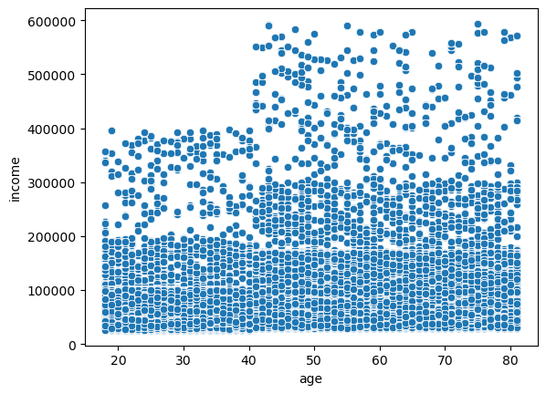

```python
scatter_2 = sns.scatterplot(x = 'age', y = 'income', data = ords_prods_cust_merge)
```

There does not appear to be a correlation between age and income. The scatterplot shows that nobody under the age of 40 makes more than 400,000/year. Most people that use instacart, across ages, make under 200,000/year.

### 8. Export visualizations.

```python
# Export scatterplot
scatter.figure.savefig(os.path.join(path, '04 Analysis','Visualizations', 'scatter_prices.png'))
```

```python
# Export line chart
line.figure.savefig(os.path.join(path, '04 Analysis','Visualizations', 'line_dow_prices.png'))
```

```python
# Export hist_hour
hist_hour.figure.savefig(os.path.join(path, '04 Analysis','Visualizations', 'hist_hour.png'))
```

```python
# Export bar_loyalty
bar_loyalty.figure.savefig(os.path.join(path, '04 Analysis','Visualizations', 'bar_loyalty.png'))
```

```python
# Export line_1
line_1.figure.savefig(os.path.join(path, '04 Analysis','Visualizations', 'line_hr_price.png'))
```

```python
# Export line_2
line_2.figure.savefig(os.path.join(path, '04 Analysis','Visualizations', 'line_fam_age.png'))
```

```python
# Export scatter_2
scatter_2.figure.savefig(os.path.join(path, '04 Analysis','Visualizations', 'scatter_age_income.png'))
```